# House price

ForozanHeidaryan

2022-12-03

# Understanding the Business Question

Price Recommendation for house Data inspection

# Dataset Description

## File descriptions

data_description.txt - full description of each column, originally prepared by Dean De Cock

but lightly edited to match the column names used here

sample_submission.csv - a benchmark submission from a linear regression on year and month of sale, lot square footage, and number of bedrooms

Data fields

Here’s a brief version of what you’ll find in the data description file.

SalePrice : the property’s sale price in dollars. This is the target variable that you’re

trying to predict.

MSSubClass: The building class

MSZoning: The general zoning classification

LotFrontage: Linear feet of street connected to property

LotArea: Lot size in square feet

Street: Type of road access

Alley: Type of alley access

LotShape: General shape of property

LandContour: Flatness of the property

Utilities: Type of utilities available

LotConfig: Lot configuration

LandSlope: Slope of property

Neighborhood: Physical locations within Ames city limits

Condition1: Proximity to main road or railroad

Condition2: Proximity to main road or railroad (if a second is present)

BldgType: Type of dwelling

HouseStyle: Style of dwelling

OverallQual: Overall material and finish quality

OverallCond: Overall condition rating

YearBuilt: Original construction date

YearRemodAdd: Remodel date

RoofStyle: Type of roof

RoofMatl: Roof material

Exterior1st: Exterior covering on house

Exterior2nd: Exterior covering on house (if more than one material)

MasVnrType: Masonry veneer type

MasVnrArea: Masonry veneer area in square feet

ExterQual: Exterior material quality

ExterCond: Present condition of the material on the exterior

Foundation: Type of foundation

BsmtQual: Height of the basement

BsmtCond: General condition of the basement

BsmtExposure: Walkout or garden level basement walls

BsmtFinType1: Quality of basement finished area

BsmtFinSF1: Type 1 finished square feet

BsmtFinType2: Quality of second finished area (if present)

BsmtFinSF2: Type 2 finished square feet

BsmtUnfSF: Unfinished square feet of basement area

TotalBsmtSF: Total square feet of basement area

Heating: Type of heating

HeatingQC: Heating quality and condition

CentralAir: Central air conditioning

Electrical: Electrical system

1stFlrSF: First Floor square feet

2ndFlrSF: Second floor square feet

LowQualFinSF: Low quality finished square feet (all floors)

GrLivArea: Above grade (ground) living area square feet

BsmtFullBath: Basement full bathrooms

BsmtHalfBath: Basement half bathrooms

FullBath: Full bathrooms above grade

HalfBath: Half baths above grade

Bedroom: Number of bedrooms above basement level

Kitchen: Number of kitchens

KitchenQual: Kitchen quality

TotRmsAbvGrd: Total rooms above grade (does not include bathrooms)

Functional: Home functionality rating

Fireplaces: Number of fireplaces

FireplaceQu: Fireplace quality

GarageType: Garage location

GarageYrBlt: Year garage was built

GarageFinish: Interior finish of the garage

GarageCars: Size of garage in car capacity

GarageArea: Size of garage in square feet

GarageQual: Garage quality

GarageCond: Garage condition

PavedDrive: Paved driveway

WoodDeckSF: Wood deck area in square feet

OpenPorchSF: Open porch area in square feet

EnclosedPorch:Enclosed porch area in square feet

3SsnPorch: Three season porch area in square feet

ScreenPorch: Screen porch area in square feet

PoolArea: Pool area in square feet

PoolQC: Pool quality

Fence: Fence quality

MiscFeature: Miscellaneous feature not covered in other categories

MiscVal: $Value of miscellaneous feature

MoSold: Month Sold

YrSold: Year Sold

SaleType: Type of sale

SaleCondition:Condition of sale

### read data from file

```r
train <- read.csv("train.csv" , header = TRUE )
```

A summary of the data

```r
dim(train)
```

```
## [1] 1460   81
```

```r
length(unique(train$Id))
```

```
## [1] 1460
```

```r
summary(train)
```

```
##        Id           MSSubClass      MSZoning          LotFrontage
##  Min.   :   1.0   Min.   : 20.0   Length:1460        Min.   : 21.00
##  1st Qu.: 365.8   1st Qu.: 20.0   Class :character   1st Qu.: 59.00
##  Median : 730.5   Median : 50.0   Mode  :character   Median : 69.00
##  Mean   : 730.5   Mean   : 56.9                      Mean   : 70.05
##  3rd Qu.:1095.2   3rd Qu.: 70.0                      3rd Qu.: 80.00
##  Max.   :1460.0   Max.   :190.0                      Max.   :313.00
##                                                      NA's   :259
##     LotArea          Street             Alley             LotShape
##  Min.   :  1300   Length:1460        Length:1460        Length:1460
##  1st Qu.:  7554   Class :character   Class :character   Class :character
##  Median :  9478   Mode  :character   Mode  :character   Mode  :character
##  Mean   : 10517
##  3rd Qu.: 11602
##  Max.   :215245
##
##  LandContour         Utilities          LotConfig          LandSlope
##  Length:1460        Length:1460        Length:1460        Length:1460
##  Class :character   Class :character   Class :character   Class :character
##  Mode  :character   Mode  :character   Mode  :character   Mode  :character
##
##
##
##
##  Neighborhood        Condition1         Condition2          BldgType
##  Length:1460        Length:1460        Length:1460        Length:1460
##  Class :character   Class :character   Class :character   Class :character
##  Mode  :character   Mode  :character   Mode  :character   Mode  :character
##
##
##
##
##   HouseStyle         OverallQual      OverallCond      YearBuilt
##  Length:1460        Min.   : 1.000   Min.   :1.000   Min.   :1872
##  Class :character   1st Qu.: 5.000   1st Qu.:5.000   1st Qu.:1954
##  Mode  :character   Median : 6.000   Median :5.000   Median :1973
##                     Mean   : 6.099   Mean   :5.575   Mean   :1971
##                     3rd Qu.: 7.000   3rd Qu.:6.000   3rd Qu.:2000
##                     Max.   :10.000   Max.   :9.000   Max.   :2010
##
```

[output cut: 113 more lines]

```
##  Min.   : 1.000   Min.   :2006   Length:1460        Length:1460
##  1st Qu.: 5.000   1st Qu.:2007   Class :character   Class :character
##  Median : 6.000   Median :2008   Mode  :character   Mode  :character
##  Mean   : 6.322   Mean   :2008
##  3rd Qu.: 8.000   3rd Qu.:2009
##  Max.   :12.000   Max.   :2010
##
##    SalePrice
##  Min.   : 34900
##  1st Qu.:129975
##  Median :163000
##  Mean   :180921
##  3rd Qu.:214000
##  Max.   :755000
##
```

Convert categorical variables to factor

```r
cat_var <- c("MSZoning" , "Street" , "Alley" ,"LotShape" , "LandContour", "Utilities" , "LotConfig" , "LandSlope" ,
             "Neighborhood" , "Condition1" , "Condition2" , "BldgType" ,
             "HouseStyle", "OverallQual", "OverallCond" , "RoofStyle" , "Exterior1st" , "Exterior2nd" , "MasVnrType",
             "ExterQual" ,"ExterCond" , "Foundation" , "BsmtQual" ,"BsmtCond" ,
             "BsmtExposure" ,"BsmtFinType1" ,"BsmtFinType2" , "Heating" , "HeatingQC" , "CentralAir" , "Electrical" ,
             "KitchenQual" , "Functional" , "Fireplaces" , "FireplaceQu" ,
             "GarageType" , "GarageFinish" , "GarageCars" , "GarageQual" ,"GarageCond" , "PavedDrive" , "PoolQC",
             "Fence","RoofMatl" ,
             "MiscFeature" , "SaleType" , "SaleCondition")
```

```r
train[,cat_var]  <-  lapply(train[,cat_var] , factor)
knitr::kable(summary(train))
```

|  | Id | MSSubClass | MSZoning | LotFrontage | LotArea | Street | Alley | LotShape | LandContour | Utilities | LotConfig | LandSlope | Neighborhood | Condition1 | Condition2 | BldgType | HouseStyle | OverallQual | OverallCond | YearBuilt | YearRemodAdd | RoofStyle | RoofMatl | Exterior1st | Exterior2nd | MasVnrType | MasVnrArea | ExterQual | ExterCond | … |
| --- | --- | --- | --- | --- | --- | --- | --- | --- | --- | --- | --- | --- | --- | --- | --- | --- | --- | --- | --- | --- | --- | --- | --- | --- | --- | --- | --- | --- | --- | --- |
|  | Min. : 1.0 | Min. : 20.0 | C (all): 10 | Min. : 21.00 | Min. : 1300 | Grvl: 6 | Grvl: 50 | IR1:484 | Bnk: 63 | AllPub:1459 | Corner : 263 | Gtl:1382 | NAmes :225 | Norm :1260 | Norm :1445 | 1Fam :1220 | 1Story :726 | 5 :397 | 5 :821 | Min. :1872 | Min. :1950 | Flat : 13 | CompShg:1434 | VinylSd:515 | VinylSd:504 | BrkCmn : 15 | Min. : 0.0 | Ex: 52 | Ex: 3 | … |
|  | 1st Qu.: 365.8 | 1st Qu.: 20.0 | FV : 65 | 1st Qu.: 59.00 | 1st Qu.: 7554 | Pave:1454 | Pave: 41 | IR2: 41 | HLS: 50 | NoSeWa: 1 | CulDSac: 94 | Mod: 65 | CollgCr:150 | Feedr : 81 | Feedr : 6 | 2fmCon: 31 | 2Story :445 | 6 :374 | 6 :252 | 1st Qu.:1954 | 1st Qu.:1967 | Gable :1141 | Tar&Grv: 11 | HdBoard:222 | MetalSd:214 | BrkFace:445 | 1st Qu.: 0.0 | Fa: 14 | Fa: 28 | … |
|  | Median : 730.5 | Median : 50.0 | RH : 16 | Median : 69.00 | Median : 9478 | NA | NA’s:1369 | IR3: 10 | Low: 36 | NA | FR2 : 47 | Sev: 13 | OldTown:113 | Artery : 48 | Artery : 2 | Duplex: 52 | 1.5Fin :154 | 7 :319 | 7 :205 | Median :1973 | Median :1994 | Gambrel: 11 | WdShngl: 6 | MetalSd:220 | HdBoard:207 | None :864 | Median : 0.0 | Gd:488 | Gd: 146 | … |
|  | Mean : 730.5 | Mean : 56.9 | RL :1151 | Mean : 70.05 | Mean : 10517 | NA | NA | Reg:925 | Lvl:1311 | NA | FR3 : 4 | NA | Edwards:100 | RRAn : 26 | PosN : 2 | Twnhs : 43 | SLvl : 65 | 8 :168 | 8 : 72 | Mean :1971 | Mean :1985 | Hip : 286 | WdShake: 5 | Wd Sdng:206 | Wd Sdng:197 | Stone :128 | Mean : 103.7 | TA:906 | Po: 1 | … |
|  | 3rd Qu.:1095.2 | 3rd Qu.: 70.0 | RM : 218 | 3rd Qu.: 80.00 | 3rd Qu.: 11602 | NA | NA | NA | NA | NA | Inside :1052 | NA | Somerst: 86 | PosN : 19 | RRNn : 2 | TwnhsE: 114 | SFoyer : 37 | 4 :116 | 4 : 57 | 3rd Qu.:2000 | 3rd Qu.:2004 | Mansard: 7 | ClyTile: 1 | Plywood:108 | Plywood:142 | NA’s : 8 | 3rd Qu.: 166.0 | NA | TA:1282 | … |
|  | Max. :1460.0 | Max. :190.0 | NA | Max. :313.00 | Max. :215245 | NA | NA | NA | NA | NA | NA | NA | Gilbert: 79 | RRAe : 11 | PosA : 1 | NA | 1.5Unf : 14 | 9 : 43 | 3 : 25 | Max. :2010 | Max. :2010 | Shed : 2 | Membran: 1 | CemntBd: 61 | CmentBd: 60 | NA | Max. :1600.0 | NA | NA | … |
|  | NA | NA | NA | NA’s :259 | NA | NA | NA | NA | NA | NA | NA | NA | (Other):707 | (Other): 15 | (Other): 2 | NA | (Other): 19 | (Other): 43 | (Other): 28 | NA | NA | NA | (Other): 2 | (Other):128 | (Other):136 | NA | NA’s :8 | NA | NA | … |

```r
knitr::kable(str(train))
```

```
## 'data.frame':    1460 obs. of  81 variables:
##  $ Id           : int  1 2 3 4 5 6 7 8 9 10 ...
##  $ MSSubClass   : int  60 20 60 70 60 50 20 60 50 190 ...
##  $ MSZoning     : Factor w/ 5 levels "C (all)","FV",..: 4 4 4 4 4 4 4 4 5 4 ...
##  $ LotFrontage  : int  65 80 68 60 84 85 75 NA 51 50 ...
##  $ LotArea      : int  8450 9600 11250 9550 14260 14115 10084 10382 6120 7420 ...
##  $ Street       : Factor w/ 2 levels "Grvl","Pave": 2 2 2 2 2 2 2 2 2 2 ...
##  $ Alley        : Factor w/ 2 levels "Grvl","Pave": NA NA NA NA NA NA NA NA NA NA ...
##  $ LotShape     : Factor w/ 4 levels "IR1","IR2","IR3",..: 4 4 1 1 1 1 4 1 4 4 ...
##  $ LandContour  : Factor w/ 4 levels "Bnk","HLS","Low",..: 4 4 4 4 4 4 4 4 4 4 ...
##  $ Utilities    : Factor w/ 2 levels "AllPub","NoSeWa": 1 1 1 1 1 1 1 1 1 1 ...
##  $ LotConfig    : Factor w/ 5 levels "Corner","CulDSac",..: 5 3 5 1 3 5 5 1 5 1 ...
##  $ LandSlope    : Factor w/ 3 levels "Gtl","Mod","Sev": 1 1 1 1 1 1 1 1 1 1 ...
##  $ Neighborhood : Factor w/ 25 levels "Blmngtn","Blueste",..: 6 25 6 7 14 12 21 17 18 4 ...
##  $ Condition1   : Factor w/ 9 levels "Artery","Feedr",..: 3 2 3 3 3 3 3 5 1 1 ...
```

[output cut: 67 more lines]

Identify missing data

```r
mv_summary2        <-  data.frame('variables name' = colnames(train))
mv_summary2$freq   <- apply(train , 2 , function(x)  sum(is.na(x)))
mv_summary2$pers   <- round(mv_summary2$freq / nrow(train) , 3) * 100
mv_summary2_1      <- as.data.frame(mv_summary2[mv_summary2$pers > 0 & mv_summary2$pers <10, ])
mv_summary2_2      <- as.data.frame(mv_summary2[mv_summary2$pers > 10 , ])
knitr::kable(mv_summary2_1)
```

|  | variables.name | freq | pers |
| --- | --- | --- | --- |
| 26 | MasVnrType | 8 | 0.5 |
| 27 | MasVnrArea | 8 | 0.5 |
| 31 | BsmtQual | 37 | 2.5 |
| 32 | BsmtCond | 37 | 2.5 |
| 33 | BsmtExposure | 38 | 2.6 |
| 34 | BsmtFinType1 | 37 | 2.5 |
| 36 | BsmtFinType2 | 38 | 2.6 |
| 43 | Electrical | 1 | 0.1 |
| 59 | GarageType | 81 | 5.5 |
| 60 | GarageYrBlt | 81 | 5.5 |
| 61 | GarageFinish | 81 | 5.5 |
| 64 | GarageQual | 81 | 5.5 |
| 65 | GarageCond | 81 | 5.5 |

```r
knitr::kable(mv_summary2_2)
```

|  | variables.name | freq | pers |
| --- | --- | --- | --- |
| 4 | LotFrontage | 259 | 17.7 |
| 7 | Alley | 1369 | 93.8 |
| 58 | FireplaceQu | 690 | 47.3 |
| 73 | PoolQC | 1453 | 99.5 |
| 74 | Fence | 1179 | 80.8 |
| 75 | MiscFeature | 1406 | 96.3 |

Removing columns that have more than 10% missing value

```r
t1 <-  train[,c("LotFrontage","Alley","FireplaceQu" ,"Fence" ,
                "MiscFeature" , "PoolQC")]
```

In my opinion, these columns have high missing values, so it causes problems in our modeling, so I preferred to remove them.

```r
train1 <- train[,-which(train %in% t1)]
dim(train1)
```

```
## [1] 1460   75
```

I also removed all the missing values in the rows. This is a good solution to get rid of the missing values

```r
train2 <- train1[apply(train1,1,function(x) any(is.na(x))) == F,]
```

For convenience, I divided the data into continuous and discrete parts

```r
cat <- train2[,c("MSZoning" , "Street" ,"LotShape" , "LandContour", "Utilities" , "LotConfig" , "LandSlope" ,
                 "Neighborhood" , "Condition1" , "Condition2" , "BldgType" ,
                 "HouseStyle", "OverallQual", "OverallCond" , "RoofStyle" , "Exterior1st" , "Exterior2nd" ,
                 "MasVnrType"    ,
                 "ExterQual" ,"ExterCond" , "Foundation" , "BsmtQual" ,"BsmtCond" ,
                 "BsmtExposure" ,"BsmtFinType1" ,"BsmtFinType2" , "Heating" , "HeatingQC" , "CentralAir" ,
                 "Electrical"  ,
                 "KitchenQual" , "Functional" , "GarageType" , "GarageFinish" , "GarageCars" , "GarageQual" ,
                 "GarageCond" , "PavedDrive" ,
                 "RoofMatl" ,
                 "SaleType" , "SaleCondition" ,"Fireplaces" )]
```

I prefer to convert the columns that contain the date field to age, this helps me more easily determine the relationship between the price and the life of the house.

```r
train3 <- train2[,-c(18,19,57,72)]
today <- as.Date("2022"  , format = "%Y")
```

```r
train3$ageBuilt <- as.Date(as.character(train2$YearBuilt) , format = "%Y")

train3$ageBuilt   <- as.numeric(today - train3$ageBuilt)

train3$ageBuilt<- round(train3$ageBuilt/365 )
summary(train3$ageBuilt)
```

```
##    Min. 1st Qu.  Median    Mean 3rd Qu.    Max.
##   12.00   21.00   46.00   48.97   66.00  142.00
```

```r
train3$ageRemodAdd  <- as.Date(as.character(train2$YearRemodAdd), format = "%Y")

train3$ageRemodAdd <- as.numeric(today - train3$ageRemodAdd)

train3$ageRemodAdd <- round(train3$ageRemodAdd / 365 )

summary(train3$ageRemodAdd)
```

```
##    Min. 1st Qu.  Median    Mean 3rd Qu.    Max.
##   12.00   18.00   27.50   36.33   54.00   72.00
```

```r
train3$GarageageBlt   <- as.Date(as.character(train2$GarageYrBlt),format = "%Y")
train3$GarageageBlt   <- as.numeric(today - train3$GarageageBlt)
train3$GarageageBlt   <-round(train3$GarageageBlt / 365 )

summary(train3$GarageageBlt)
```

```
##    Min. 1st Qu.  Median    Mean 3rd Qu.    Max.
##    12.0    20.0    42.0    43.4    60.0   122.0
```

```r
#Regarding the sale date, it also helps me to better recognize the rise and fall of prices
train3$ageSold  <- as.Date(as.character(train2$YrSold) , format = "%Y")
train3$ageSold  <- as.numeric(today - train3$ageSold)
train3$ageSold  <- round(train3$ageSold / 365 )
summary(train3$ageSold)
```

```
##    Min. 1st Qu.  Median    Mean 3rd Qu.    Max.
##   12.00   13.00   14.00   14.19   15.00   16.00
```

Regarding the sale date, it also helps me to better recognize the rise and fall of prices

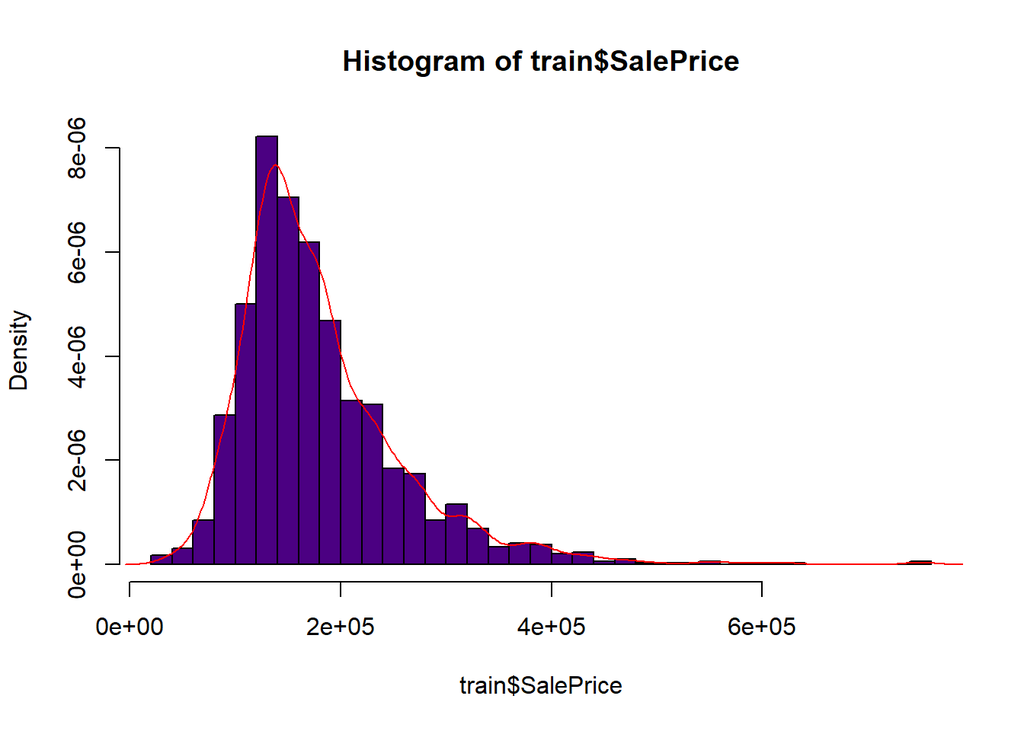

```r
par(mfrow = c(1,1))
hist(train$SalePrice , breaks = 50,probability = TRUE , col = "#4B0082")
lines(density(train$SalePrice) , col = "red")
```

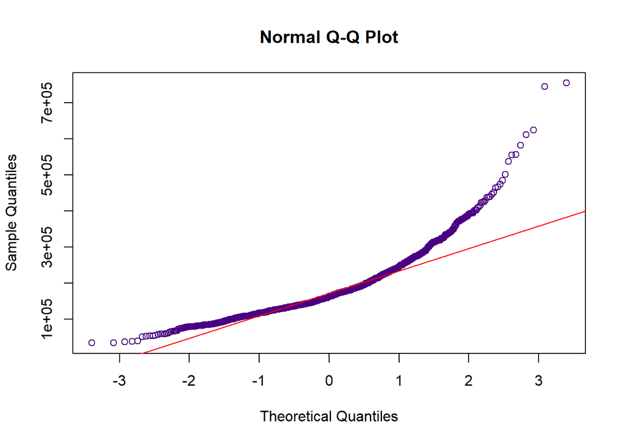

```r
qqnorm(train$SalePrice , col = "#4B0082")
qqline(train$SalePrice , col = "red")
```

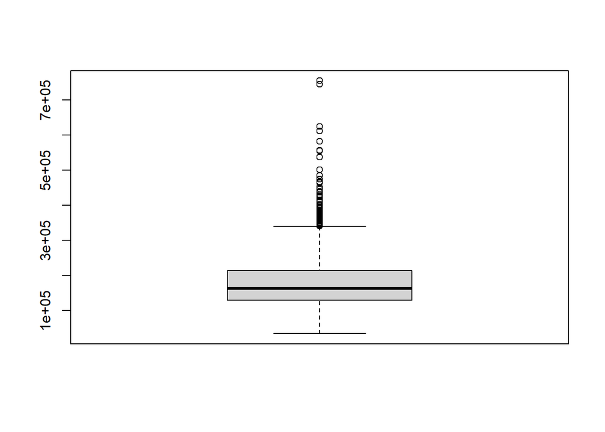

```r
par(mfrow = c(1,1))
boxplot(train$SalePrice)
```

```r
library("moments")

jarque.test(train$SalePrice)
```

```
##
##  Jarque-Bera Normality Test
##
## data:  train$SalePrice
## JB = 3438.9, p-value < 2.2e-16
## alternative hypothesis: greater
```

```r
#pvalue < 0   -> h0 regect
```

The graphs and statistical tests indicate that the response variable does not follow a normal distribution, which makes sense to me because a smaller percentage of people are very wealthy.I would like to approximate them to a normal distribution, this may help me For this purpose, I use Box Cox conversion

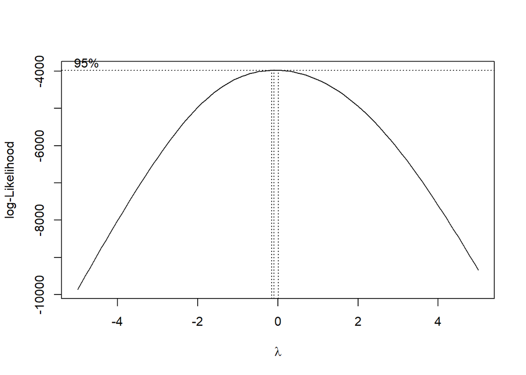

```r
library("MASS")
box_result <- boxcox(train$SalePrice ~ 1 , lambda = seq(-5 , 5 , 0.1))
```

```r
box_result <- data.frame(box_result)
lambda <- box_result[which(box_result$y == max(box_result$y)),]
salPrice <- log(train$SalePrice)
```

It is clear that zero is inside this confidence interval Therefore, I use logarithmic transformation

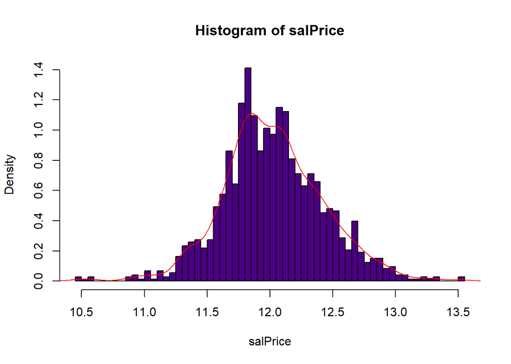

```r
hist(salPrice , breaks = 50 , probability = TRUE , col = "#4B0082")
lines(density(salPrice) , col = "red")
```

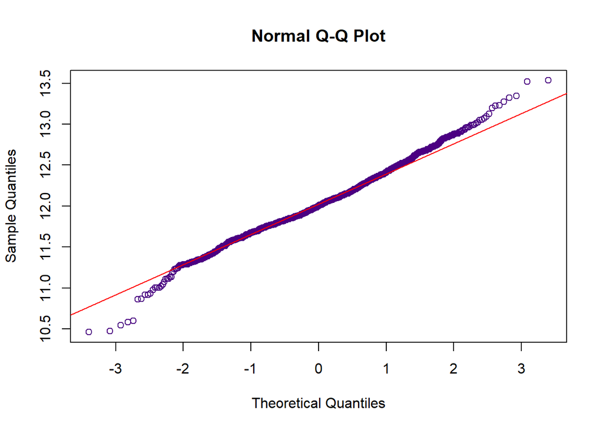

```r
qqnorm(salPrice , col = "#4B0082")
qqline(salPrice , col = "red")
```

```r
jarque.test(salPrice)
```

```
##
##  Jarque-Bera Normality Test
##
## data:  salPrice
## JB = 42.767, p-value = 5.167e-10
## alternative hypothesis: greater
```

```r
anscombe.test(salPrice)
```

```
##
##  Anscombe-Glynn kurtosis test
##
## data:  salPrice
## kurt = 3.8027, z = 4.6820, p-value = 2.84e-06
## alternative hypothesis: kurtosis is not equal to 3
```

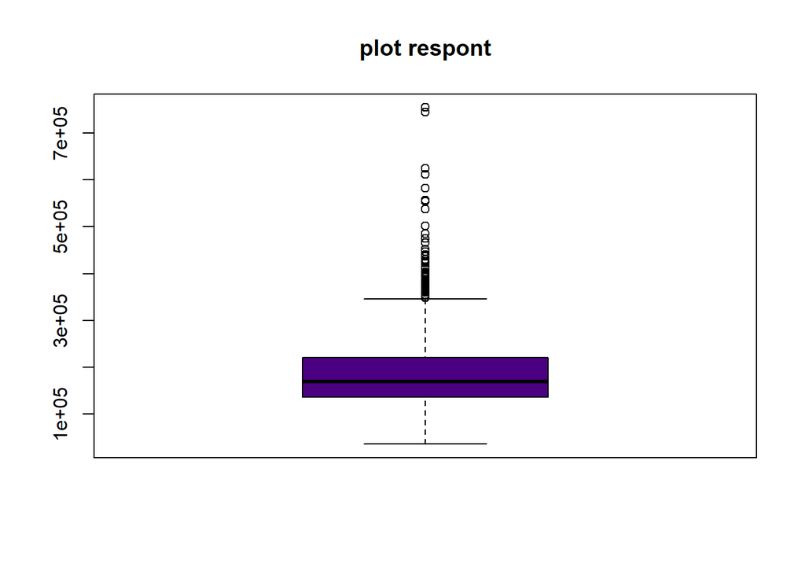

```r
par(mfrow = c(1,1))
boxplot(train3$SalePrice ,main = "plot respont", col = "#4B0082")
```

It seems that the data is far from the normal distribution

```r
tukey_u <- quantile(train3$SalePrice , probs = 0.75) + 1.5 * IQR(train3$SalePrice)

sum(train3$SalePrice > tukey_u)
```

```
## [1] 56
```

The number of continuous data is very high, so I will convert them into two parts

```r
count <- train3[,-which(train3 %in% cat)]
cunt1 <- count[,c(1:17)]
cunt2 <- count[,c(18:33)]

cunt1 <- cunt1[,-1]
cunt1$SalePrice  <- cunt2$SalePrice
```

Histogram of continuous data

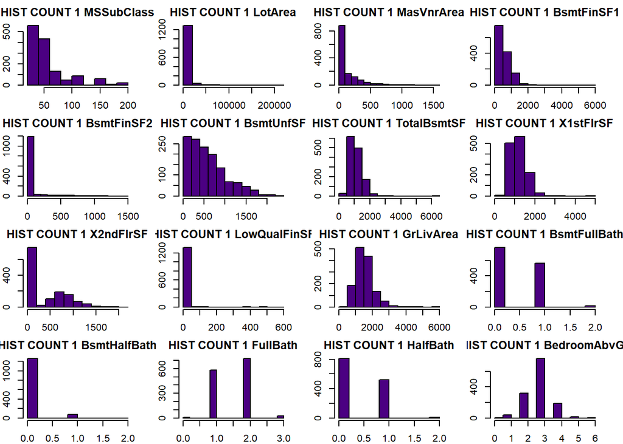

```r
par(mar = c(2,2,2,2))
par(mfrow = c(4,4))
for (i in 1:16 ) {
  hist(cunt1[,i] , xlab =   "" ,col = "#4B0082", main = paste("HIST COUNT 1" ,
                                                              names(cunt1[i])))
}
```

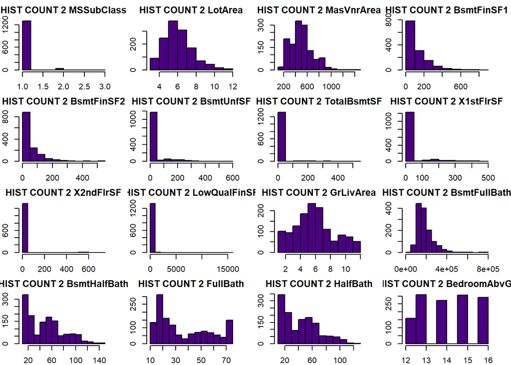

```r
par(mar = c(2,2,2,2))
par(mfrow = c(4,4))
for (i in 1:16) {
  hist(cunt2[,i] , xlab = "" , col = "#4B0082" , main = paste("HIST COUNT 2" ,
                                                              names(cunt1[i])))
}
```

Checking the correlation of continuous data with the response variable

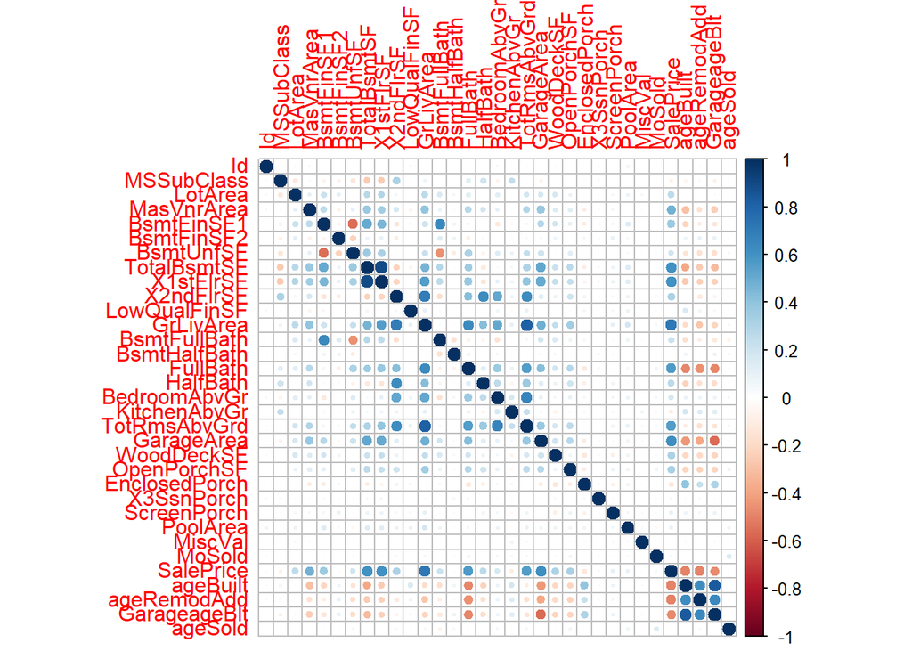

```r
cros_tab <- round(cor(count),2)

library("corrplot")
par(mfrow = c(1,1))
corrplot(cros_tab)
```

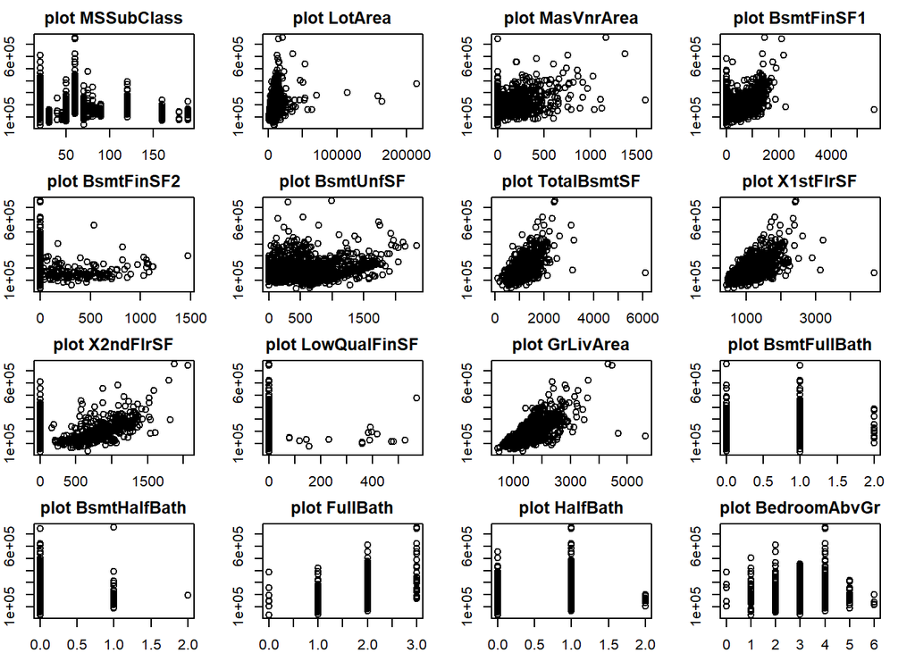

```r
par(mar=c(2,2,2,2))
par(mfrow = c(4,4))
for (i in 1:16) {
  plot(cunt1[,i] , cunt2$SalePrice,xlab = "" , main = paste("plot" ,names(cunt1)[i] ))
}
```

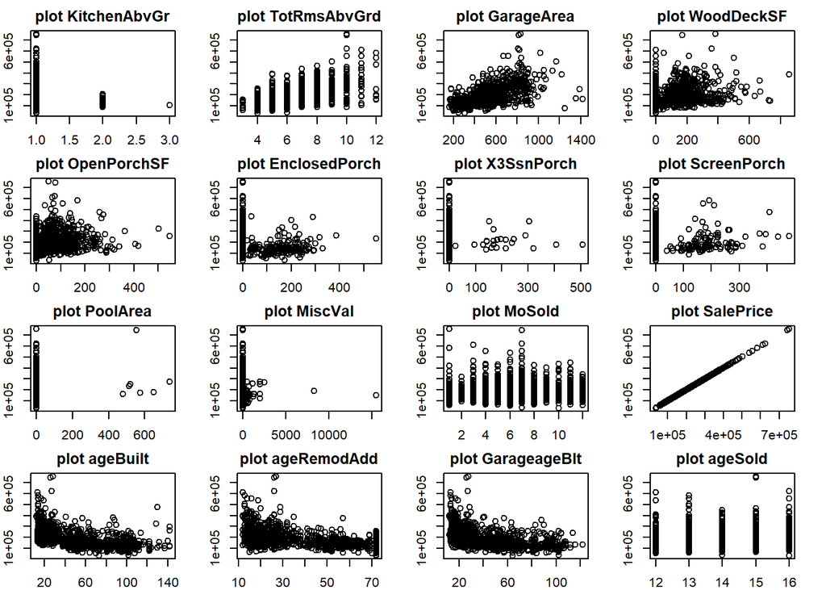

```r
par(mar=c(2,2,2,2))
par(mfrow = c(4,4))
for (i in 1:16) {
  plot(cunt2[,i] , cunt2$SalePrice,xlab = "" , main = paste("plot" ,names(cunt2)[i] ))
}
```

I put the columns that contain discrete variables in one file

```r
categori <- train2[,which( train2 %in% cat)]
colnames(categori)
```

```
##  [1] "MSZoning"      "Street"        "LotShape"      "LandContour"
##  [5] "Utilities"     "LotConfig"     "LandSlope"     "Neighborhood"
##  [9] "Condition1"    "Condition2"    "BldgType"      "HouseStyle"
## [13] "OverallQual"   "OverallCond"   "RoofStyle"     "RoofMatl"
## [17] "Exterior1st"   "Exterior2nd"   "MasVnrType"    "ExterQual"
## [21] "ExterCond"     "Foundation"    "BsmtQual"      "BsmtCond"
## [25] "BsmtExposure"  "BsmtFinType1"  "BsmtFinType2"  "Heating"
## [29] "HeatingQC"     "CentralAir"    "Electrical"    "KitchenQual"
## [33] "Functional"    "Fireplaces"    "GarageType"    "GarageFinish"
## [37] "GarageCars"    "GarageQual"    "GarageCond"    "PavedDrive"
## [41] "SaleType"      "SaleCondition"
```

```r
dim(categori)
```

```
## [1] 1338   42
```

Examining each variable with the response variable

```r
table(train3$MSZoning)
```

```
##
## C (all)      FV      RH      RL      RM
##       8      62      11    1066     191
```

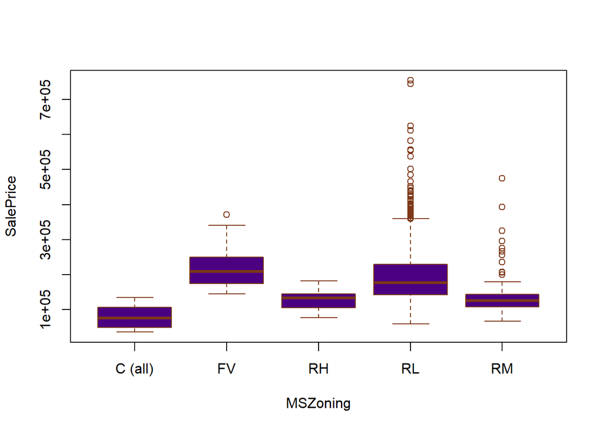

```r
boxplot(SalePrice ~ MSZoning , data = train3 , col = "#4B0082" , border = "#7E3817")
```

```r
table(train3$Street)
```

```
##
## Grvl Pave
##    5 1333
```

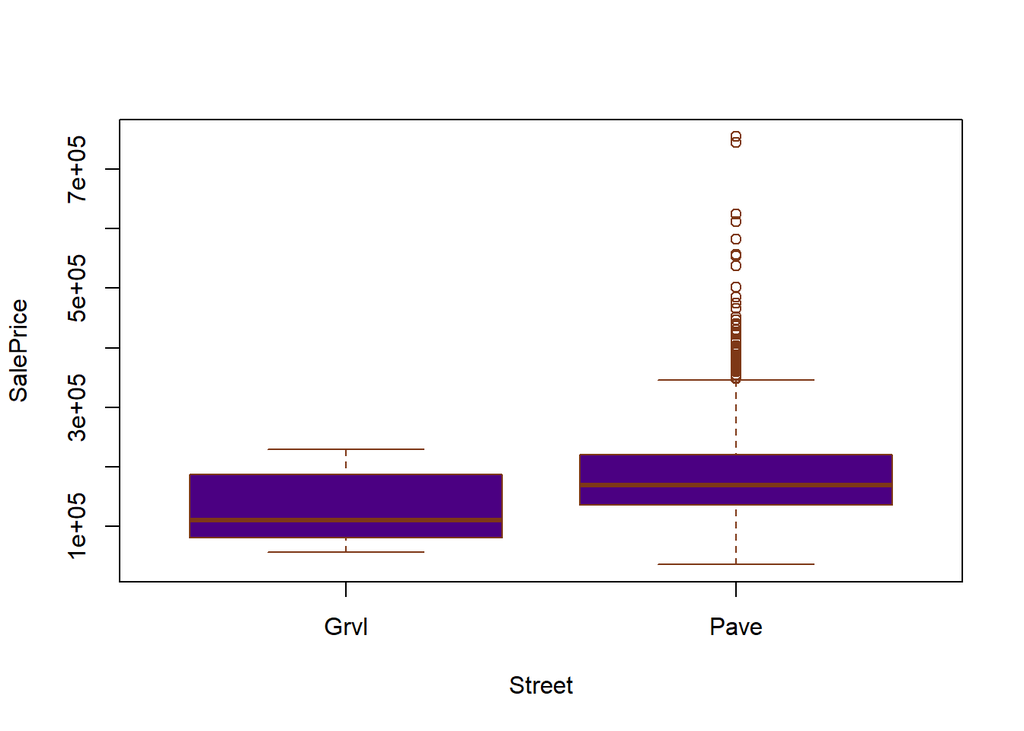

```r
boxplot(SalePrice ~  Street , data = train3 , col = "#4B0082" , border = "#7E3817")
```

The type of Paved street has a great effect on the price. It seems that these houses are located in a more expensive area

```r
table(train3$LotShape)
```

```
##
## IR1 IR2 IR3 Reg
## 459  40  10 829
```

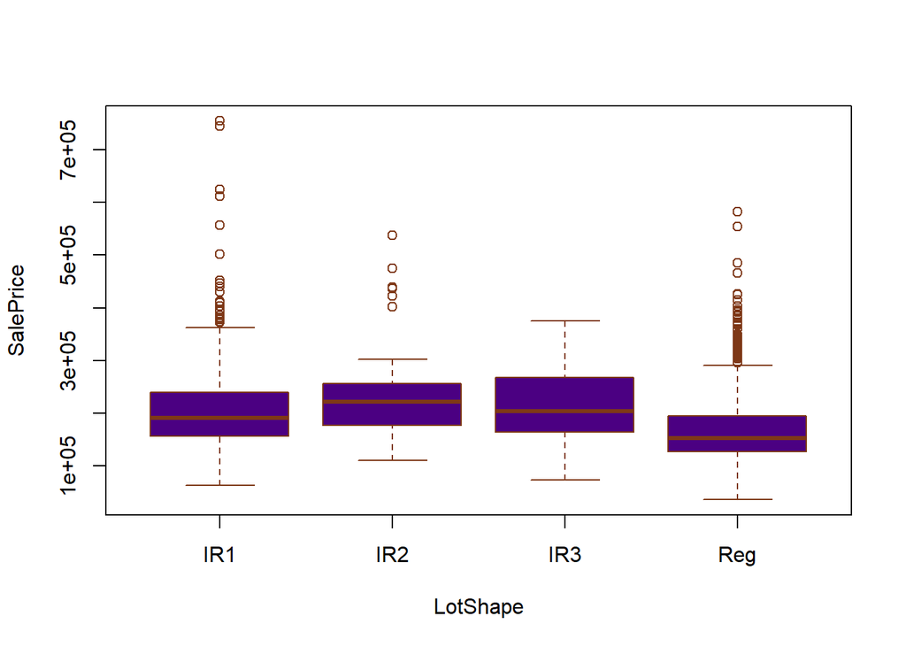

```r
boxplot(SalePrice ~ LotShape , data = train3 , col = "#4B0082" , border = "#7E3817")
```

```r
table(train3$LandContour)
```

```
##
##  Bnk  HLS  Low  Lvl
##   52   48   32 1206
```

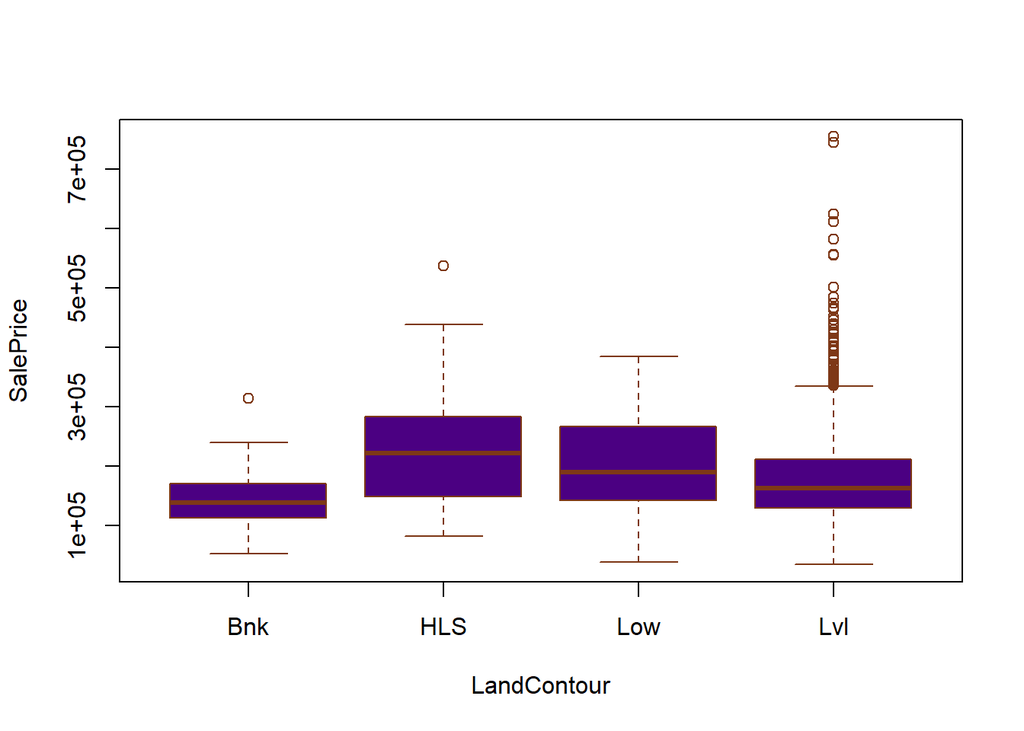

```r
boxplot(SalePrice ~ LandContour , data = train , col = "#4B0082" , border = "#7E3817")
```

```r
table(train3$Utilities)
```

```
##
## AllPub NoSeWa
##   1337      1
```

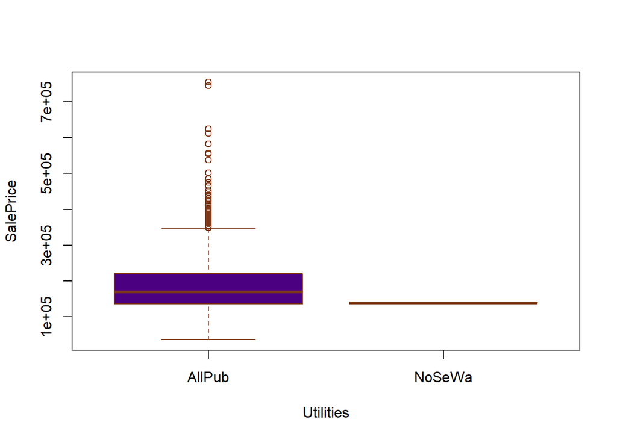

```r
boxplot(SalePrice ~  Utilities , data = train3 , col = "#4B0082" , border = "#7E3817")
```

```r
table(train3$LotConfig)
```

```
##
##  Corner CulDSac     FR2     FR3  Inside
##     244      90      43       4     957
```

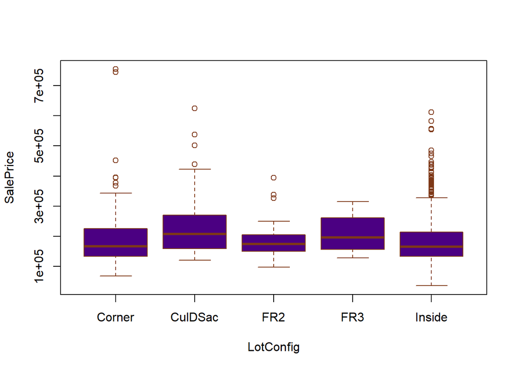

```r
boxplot(SalePrice ~  LotConfig , data = train3 , col = "#4B0082" , border = "#7E3817")
```

```r
table(train3$LandSlope)
```

```
##
##  Gtl  Mod  Sev
## 1265   61   12
```

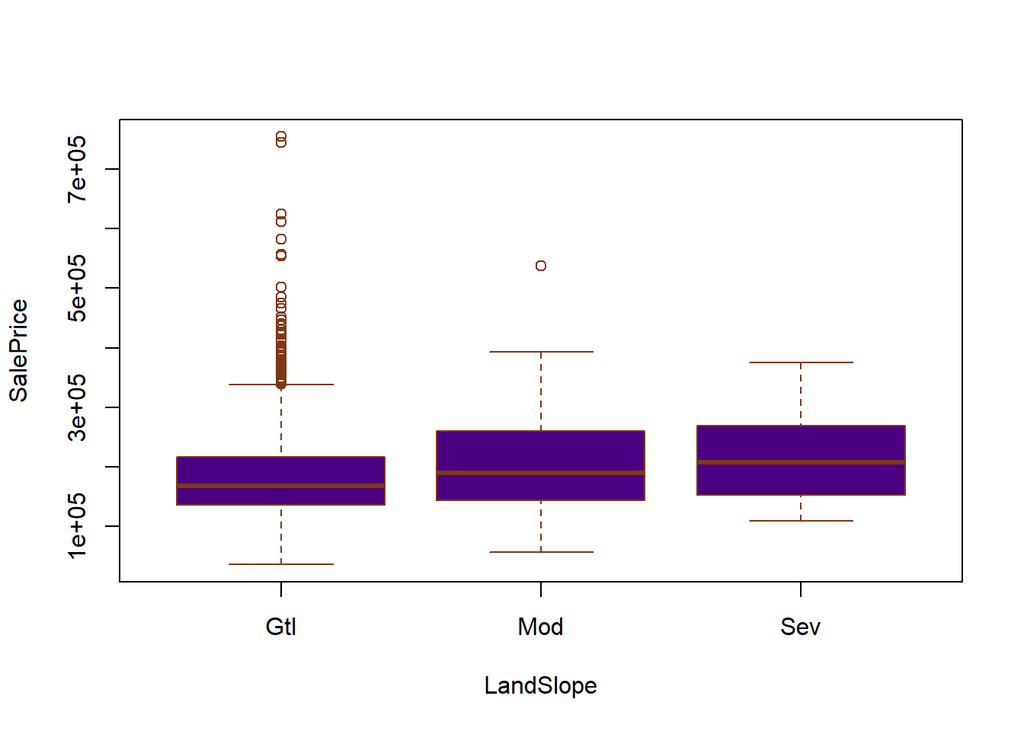

```r
boxplot(SalePrice ~  LandSlope , data = train3 , col = "#4B0082" , border = "#7E3817")
```

```r
table(train3$Neighborhood)
```

```
##
## Blmngtn Blueste  BrDale BrkSide ClearCr CollgCr Crawfor Edwards Gilbert  IDOTRR
##      17       2      15      47      26     146      50      70      77      29
## MeadowV Mitchel   NAmes NoRidge NPkVill NridgHt  NWAmes OldTown  Sawyer SawyerW
##      12      42     209      41       9      75      73     100      69      53
## Somerst StoneBr   SWISU  Timber Veenker
##      83      25      20      37      11
```

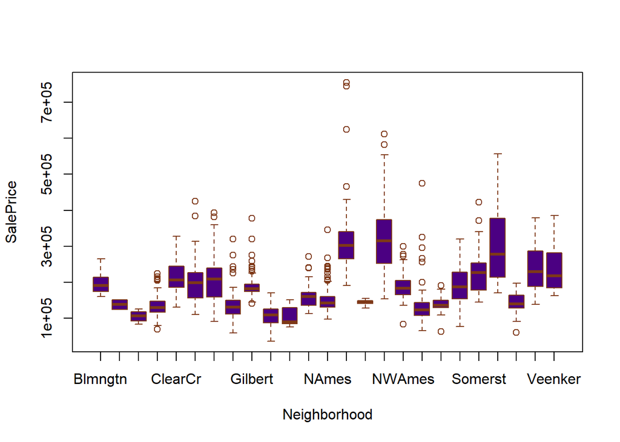

```r
boxplot(SalePrice ~ Neighborhood , data = train3 , col = "#4B0082" , border = "#7E3817")
```

```r
table(train3$Condition1)
```

```
##
## Artery  Feedr   Norm   PosA   PosN   RRAe   RRAn   RRNe   RRNn
##     43     63   1162      8     19     10     26      2      5
```

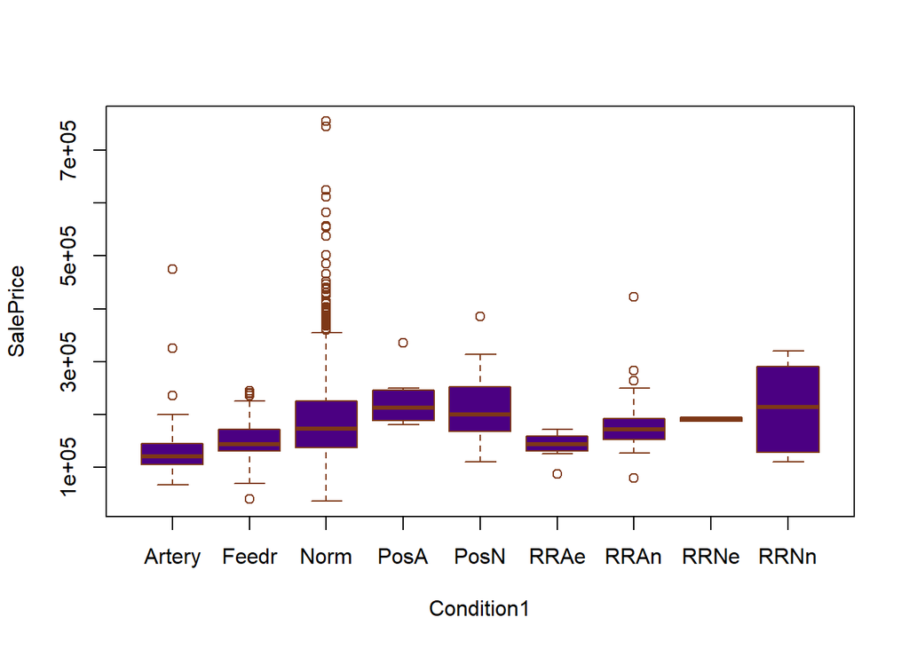

```r
boxplot(SalePrice ~ Condition1 , data = train3 , col = "#4B0082" , border = "#7E3817")
```

```r
table(train3$Condition2)
```

```
##
## Artery  Feedr   Norm   PosA   PosN   RRAe   RRAn   RRNn
##      2      5   1324      1      2      1      1      2
```

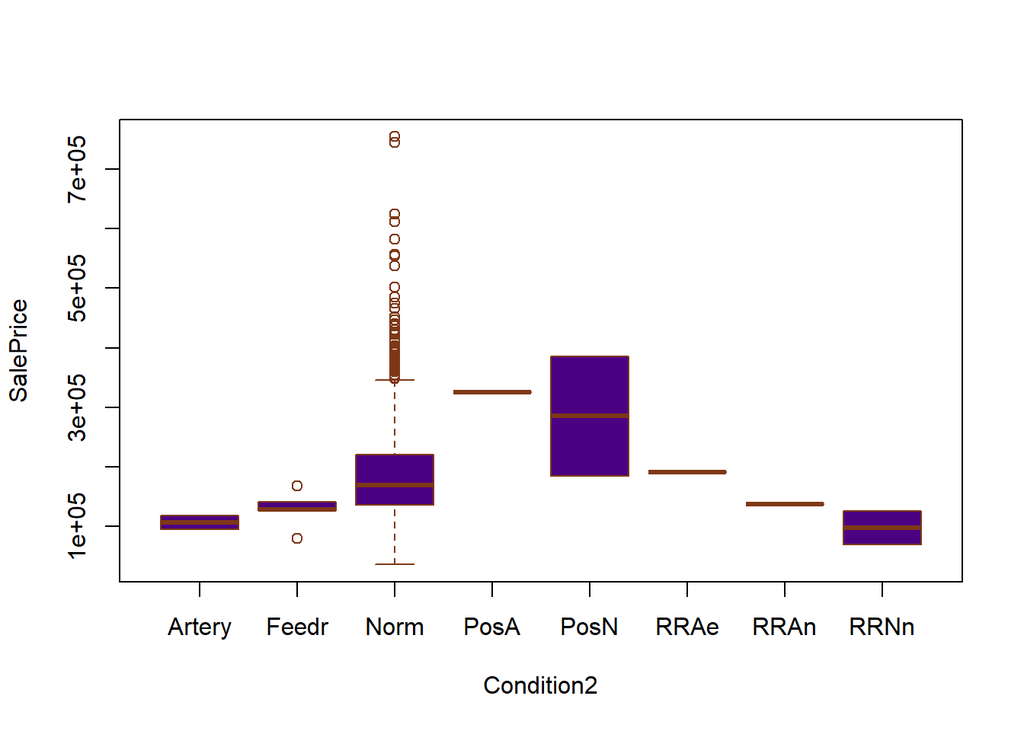

```r
boxplot(SalePrice ~ Condition2 , data = train3 , col = "#4B0082" , border = "#7E3817")
```

```r
table(train3$BldgType)
```

```
##
##   1Fam 2fmCon Duplex  Twnhs TwnhsE
##   1138     22     28     38    112
```

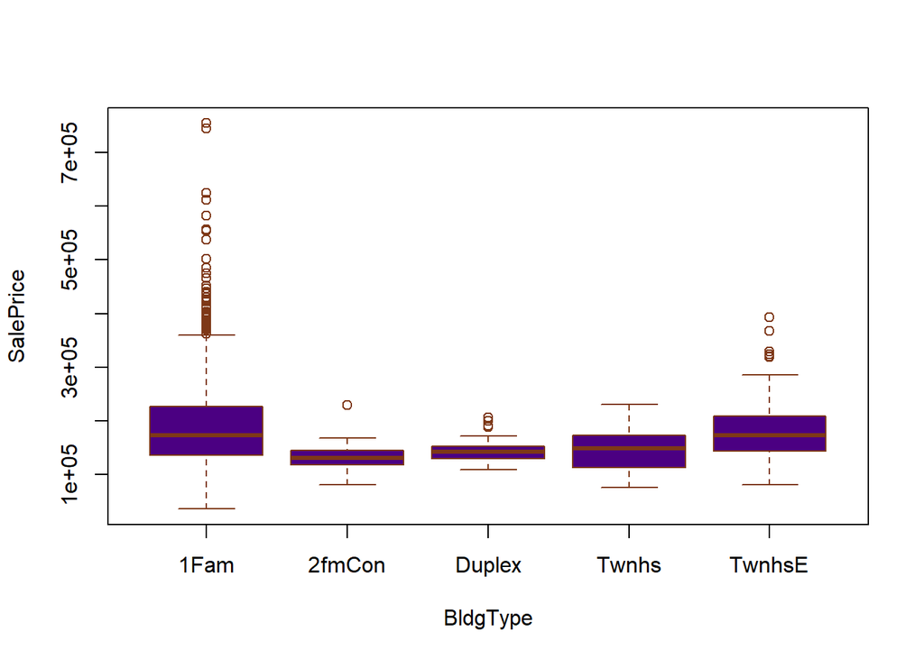

```r
boxplot(SalePrice ~ BldgType , data = train3 , col = "#4B0082" , border = "#7E3817")
```

```r
table(train3$HouseStyle)
```

```
##
## 1.5Fin 1.5Unf 1Story 2.5Fin 2.5Unf 2Story SFoyer   SLvl
##    134     11    657      6     10    426     30     64
```

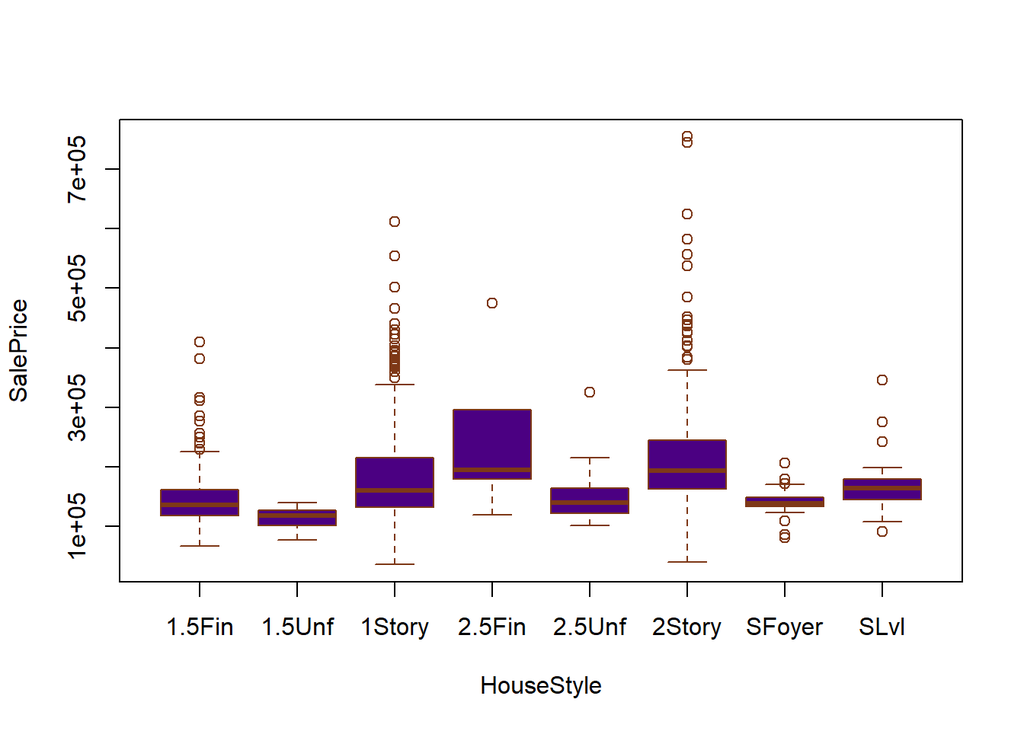

```r
boxplot(SalePrice ~ HouseStyle , data = train3 , col = "#4B0082" , border = "#7E3817")
```

```r
table(train3$OverallQual)
```

```
##
##   1   2   3   4   5   6   7   8   9  10
##   0   2   8  81 351 359 312 165  43  17
```

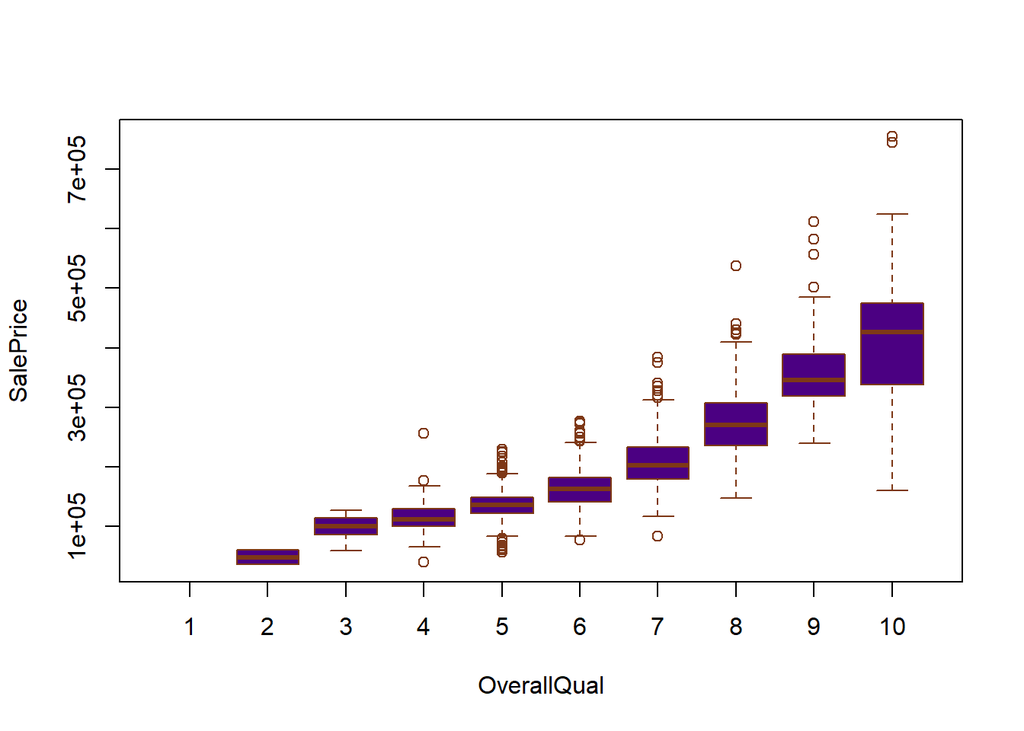

```r
boxplot(SalePrice ~ OverallQual , data = train3 , col = "#4B0082" , border = "#7E3817")
```

```r
table(train3$OverallCond)
```

```
##
##   1   2   3   4   5   6   7   8   9
##   0   3  15  46 770 233 183  68  20
```

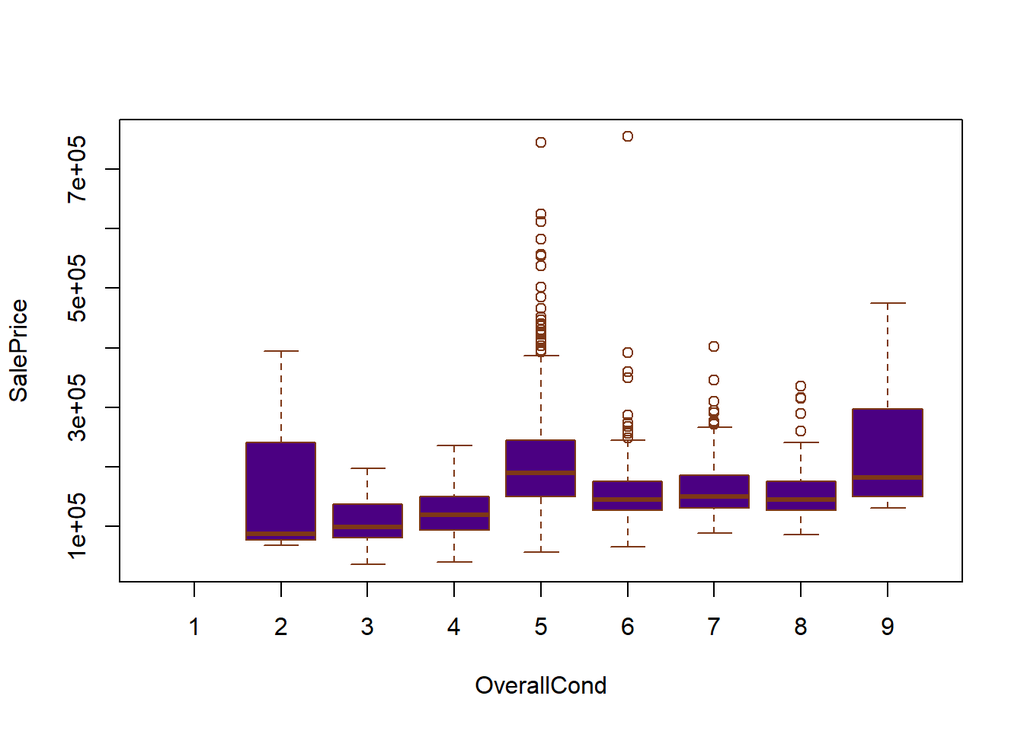

```r
boxplot(SalePrice ~ OverallCond , data = train3 , col = "#4B0082" , border = "#7E3817")
```

```r
table(train3$RoofStyle)
```

```
##
##    Flat   Gable Gambrel     Hip Mansard    Shed
##      11    1037      10     272       6       2
```

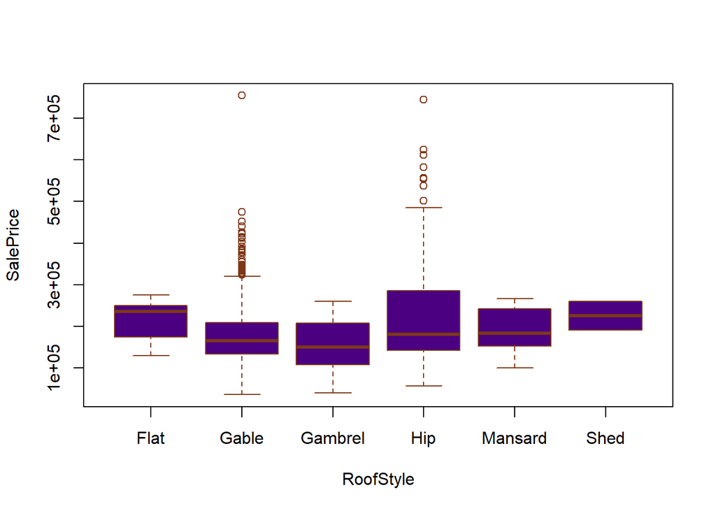

```r
boxplot(SalePrice ~ RoofStyle , data = train3 , col = "#4B0082"  , border = "#7E3817")
```

```r
table(train3$RoofMatl)
```

```
##
## ClyTile CompShg Membran   Metal    Roll Tar&Grv WdShake WdShngl
##       1    1314       1       1       1       9       5       6
```

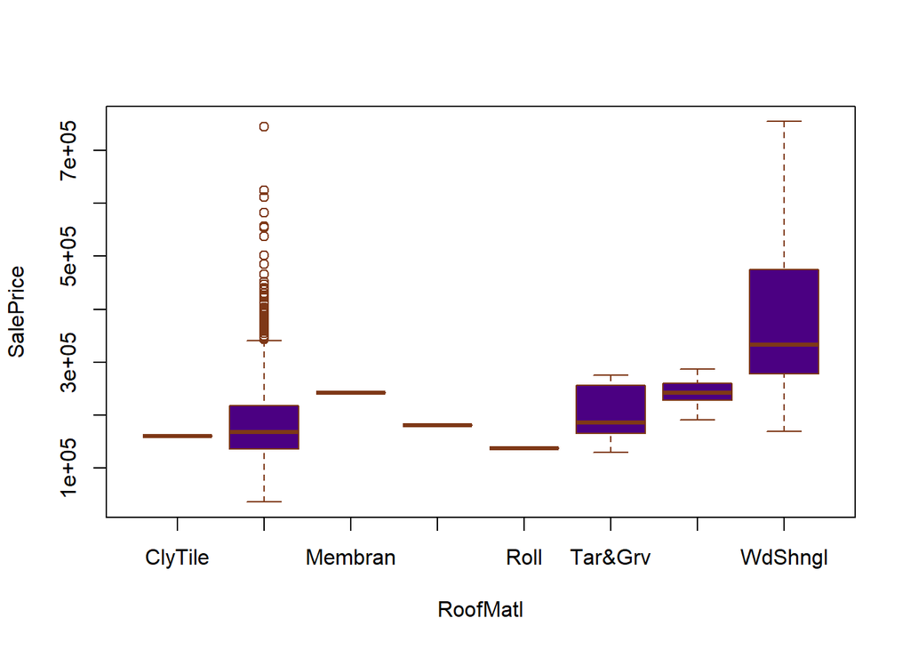

```r
boxplot(SalePrice ~  RoofMatl , data = train3 , col = "#4B0082" , border = "#7E3817")
```

```r
table(train3$Exterior1st)
```

```
##
## AsbShng AsphShn BrkComm BrkFace  CBlock CemntBd HdBoard ImStucc MetalSd Plywood
##      15       0       1      44       1      52     211       1     201     100
##   Stone  Stucco VinylSd Wd Sdng WdShing
##       2      21     486     183      20
```

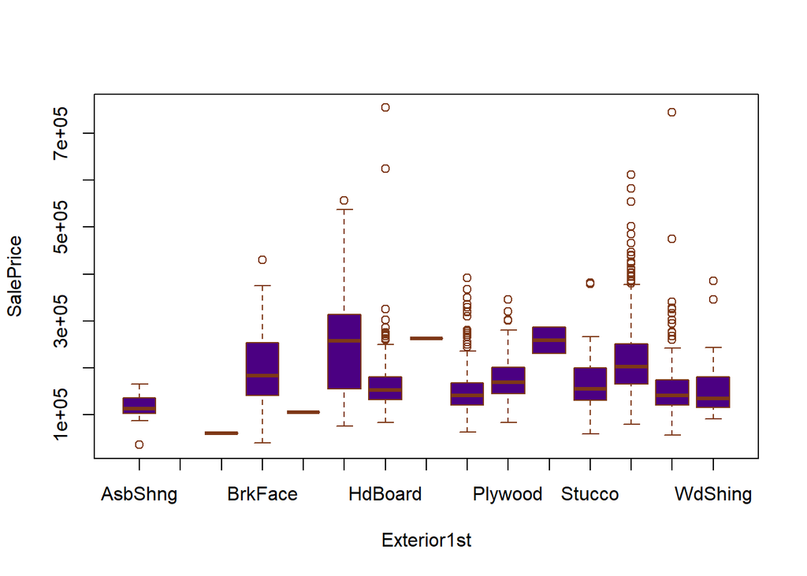

```r
boxplot(SalePrice ~ Exterior1st , data = train3 , col = "#4B0082" , border = "#7E3817")
```

```r
table(train3$Exterior2nd)
```

```
##
## AsbShng AsphShn Brk Cmn BrkFace  CBlock CmentBd HdBoard ImStucc MetalSd   Other
##      16       2       6      22       1      51     197      10     197       1
## Plywood   Stone  Stucco VinylSd Wd Sdng Wd Shng
##     127       2      23     475     176      32
```